# The Schrödinger Wavefunction: Visualized

This is a kind of demonstration, or a preview of some of the animation capabilities that the QMsolve python module has. Since one of the premier uses of programming is in computer animation/mathematical modelling, what better way to do so than to animate one of the most principle models in our entire universe's standard model: the schrodinger wave equation.

This mini-report of mine was written in Jupyter Notebooks, which is an open-source web baesd application that is used by a variety of people-- from mathematicians and data scientists-- to programmers and developers in order to integrate live code, mathematics, visualizations, and other multimedia resources such as markdown for text.

## A Brief Introduction to Quantum Mechanics and the Schrödinger Equation

One of the fundamental propositions of the 1920s came from the French physicist Louis de Brogile, in which he proposed a possible hypothesis to explain the theory of the atomic structure. De Brogile hypothesizes, through a series of derivations, that all particles and quantum entities of the like also hold properties of waves. A few years later in 1927, Clinton Davisson and Lester Germer conducted the Davisson-Germer experiment, in which they bombarded slitted metals with electrons in a similar fashion to the double-slit experiment. They both observed visible diffraction patterns afterwards, confirming De Brogile's proposition of the wave-particle duality.

When looking at a quantum system in one dimension, we can model the dynamics of said system using the time-dependent form of Schrödinger's Equation:

$$i\hbar\frac{\partial \psi}{\partial t} = \frac{-\hbar^2}{2m} \frac{\partial^2 \psi}{\partial x^2} + V \psi$$

where $\hbar$ represents the quantization of angular momentum, or the reduced planck constant $\frac{h}{2\pi}$, $h$ being planck's constant. $m$ represents the mass of the particle, and $V$ represents the potential energy.

In the equation above, $\psi(x, t)$ represents the wavefunction, or a model to find the probability of finding a particle at an exact location $x$ and at an exact point in time $t$. The format of this equation is what we call a *differential equation*, or an equation that relates the rate of change of two quantities to each other; in this case, we are relating the rates of change of position of a particle with the passage of time, in respect to a realm where things are so small, we cannot describe them using the normal laws of physics. There are two forms of the Schrödinger equation; this one in which we see time directly appear in, modelling how the wave-like behavior of an extremely miniscule particle evolves in time -- and one in which the time variable is removed, appropriately called Schrödinger's time-*independent* wavefunction. This can be easily derived from the time dependent equation by one with a rather strong background in differential calculus (unless the energy potential of a particle is also time-dependent, a case which will not be discussed here). The time-independent version is normally one that just relays the energy thresholds of the particles.

### Beginning the Visualization and Solving

I will be using the qmsolve module in order to provide animations, and it will make the simulations a lot smoother. You can install qmsolve directly via your terminal using

```
$ pip install qmsolve
```

For 3D simulations, you would also require the Mayavi package, which is

```
$ pip install mayavi
```

Recall that $$i\hbar\frac{\partial \psi}{\partial t} = \frac{-\hbar^2}{2m} \frac{\partial^2 \psi}{\partial x^2} + V \psi$$ within just a single dimension. And yes, this is implying that it is indeed possible to extrapolate the Schrödinger equation into higher dimensions. For this, we would need a shortened equation. Fortunately, we have just the right thing.

Note that the quantum operator for kinetic energy is derived from the classical physics energy equation $p^2/2m$ by setting $p \rightarrow -i\hbar\nabla$. This is an example of the Correspondence Principle proposed by Niehl's Bohr postulating that the behavior model of quantum systems slowly approaches a rough reproduction of classical systems as quantum numbers reach arbitrarily large limits.

Essentially this means that using this operator to represent the total energy within a quantum system, we can redescribe Schrödinger's equation in a more readable form:

$$i\hbar\frac{\partial \psi}{\partial t} = \hat{H}\psi$$

Discretizing the Hamiltonian is going to be absolutely cardinal in how we define the parameters behind the wavefunctions and build the animations.

There are a number of ways to go about solving this, such as using a finite difference, a Fourier split-step method, Crank Nicholson, but let's make this a little easier on us.

#### The first assertion: The Schrödinger equation is just an eigenvalue problem in disguise

An operator acting upon a function normally just outputs another function, but what happens when we have an operator $\hat{O}$ acting upon another function $\psi$, and we have a new function that's proportional to the original? $$\hat{O}\psi \propto \psi$$

In this case, we could express the transform via an equation by introducing a proportionality constant $\lambda$: $$\hat{O}\psi = \lambda \psi$$

We have that for a function $\psi$ that fits this equality, it is an **eigenfunction** of the operator $\hat{O}$ with $\lambda$ being the **eigenvalue** of $\hat{O}$. You will see these terms a lot in linear algebra courses, so it may help to keep them in mind down the road.

It is a general principle of Quantum Mechanics that there is a quantum operator associated with every possible observable physical quantity. In simpler terms, this means for every physical, we can define a transformation that takes each physical quantity and redefines it to fit the strange mechanics that permeate the quantum universe. If the wavefunction that describes a system is an eigenfunction of the operator, then we can extract the observable physical quantity from the eigenfunction by applying the appropriate operator on the eigenfunction. The resulting observable value for the system is the eigenvalue, and the system is said to be in an **eigenstate**.

Now, we can finally implement the tools from QMsolve that we can use to extract these eigenstates and eigenvalues given an operator, and then we can plot the eigenstates as an animation.

First, let's install the necessary packages:

```python
import numpy as np
from qmsolve import Hamiltonian,  SingleParticle, init_visualization, Å,eV
```

To start off, let's start by defining the Hamiltonian of a single particle confined within a harmonic oscillator potential. From there, we compute -- and plot -- the respective eigenstates.

First things first, we define an interaction potential for a particle via the `harmonic_oscilator` object:

```python
def harmonic_oscillator(particle):
    k = 100 * eV / Å**2
    return 0.5 * k * particle.x**2 #we have defined the interaction potential for this particle
```

Next up comes the part where we define our Hamiltonian via the parameters within the `Hamiltonian()` object within the QMSolve module, utilizing the `harmonic_oscillator` object from earlier as our potential:

```python
# defining the Hamiltonian:
H = Hamiltonian(particles = SingleParticle(),
                potential = harmonic_oscillator, spatial_ndim = 1, N = 512, extent = 20*Å)
```

The next step is to diagonalize the Hamiltonian operator (which is in the form of a matrix here) and to extract eigenstates:

```python
states = H.solve(max_states = 30)
```

```
Computing...
Took 0.5086719989776611
```

[figure not shown]

```python
x = np.linspace(-1.0*Å, 1.0*Å, len(states.array[0]))
w0 = np.exp(-(x-0.16*Å)**2/(2*(0.05*Å)**2))

"""From here, we compute the inner dot product of the initial state of w0(x) with the eigenstates w_n(x),
   so everything in this array "coeff" is essentially coeff = w_n|w0>
"""

coeffs = np.dot(states.array, w0)*1.0j
```

We are very nearly done here. All that's left is to actually visualize a superposition of the real and imaginary portions of our wavefunction using `init_visualization`

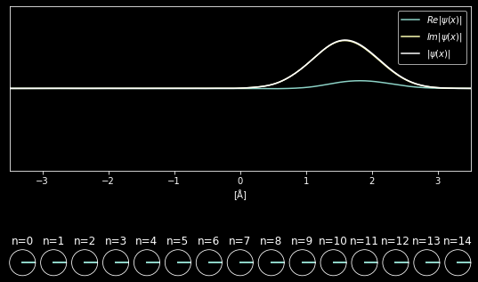

```python
vis = init_visualization(states)
vis.superpositions(coeffs[0:15], xlim=[-3.5*Å, 3.5*Å])
```

Putting it as a script named `vis.py` and running `python vis.py` in the terminal will give a beautifully animated display of these superpositions, as shown below:

[figure not shown]